# SuperMap tutorial

In this tutorial, we showcase an example of integrating protein and ATAC modality. We use an ASAP-seq dataset downloaded from GEO (accession ID: GSE156478), which contains antibody-derived tag measurements for 227 proteins along with genome-wide chromatin accessibility profiles.

## Necessary packages

In order to run this vignette, make sure the following packages are installed:

```r
library(SuperMap)
library(dplyr)
library(ggplot2)
library(Seurat)
library(Signac)
library(GenomicRanges)
library(GenomeInfoDb)
library(EnsDb.Hsapiens.v86)
library(Matrix)
library(stringr)
library(tidyr)
library(RColorBrewer)
library(BiocParallel)
```

## Stage 1: Data processing

We begin by loading the downloaded dataset, which includes both ADT and scATAC-seq measurements.

```r
atac_count = readRDS('ASAP_data/atac_count.RDS')
adt_matrix = readRDS('ASAP_data/adt_matrix.RDS')
cell_type= read.csv('ASAP_data/asapseq_control_cellTypes.csv')
```

We create SeuratObject for the ADT and ATAC data, then perform preprocessing for each modality.

```r
pbmc_adt = CreateSeuratObject(counts = t(adt_matrix),assay = 'ADT')
pbmc_adt = NormalizeData(pbmc_adt)
```

```
## Normalizing layer: counts
```

```r
pbmc_adt = ScaleData(pbmc_adt)
pbmc_adt = RunPCA(pbmc_adt,features = rownames(pbmc_adt),verbose = FALSE)
pbmc_adt = RunUMAP(pbmc_adt,dims = 1:50)
pbmc_adt = FindNeighbors(object = pbmc_adt, reduction = 'pca', dims = 1:50)
```

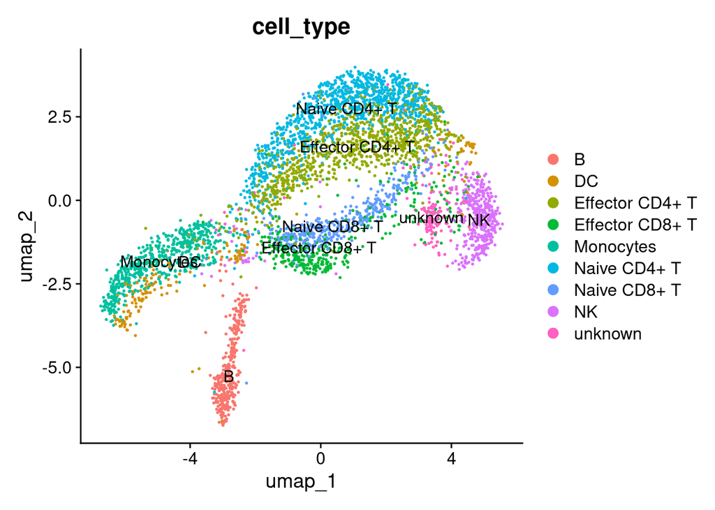

```r
pbmc_adt$cell_type = cell_type$x
DimPlot(pbmc_adt,reduction = 'umap',label = TRUE,group.by = 'cell_type')
```

We further perform preprocessing and visualization for ATAC data.

```r
chrom_assay <- CreateChromatinAssay(
  counts = atac_count,
  sep = c("-", "-"),
  fragments = "ASAP_data/GSM4732109_CD28_CD3_control_ASAP_fragments.tsv.gz")
```

```
## Computing hash
```

```r
pbmc_atac <- CreateSeuratObject(counts = chrom_assay,assay = "ATAC")
pbmc_atac$cell_type = cell_type$x

pbmc_atac <- RunTFIDF(pbmc_atac)
```

```
## Performing TF-IDF normalization
```

```r
pbmc_atac <- FindTopFeatures(pbmc_atac, min.cutoff = 'q0')
pbmc_atac <- RunSVD(pbmc_atac)
```

```
## Running SVD
```

```
## Scaling cell embeddings
```

```r
pbmc_atac <- RunUMAP(pbmc_atac, reduction = 'lsi', dims = 2:50)
pbmc_atac <- FindNeighbors(object = pbmc_atac, reduction = 'lsi', dims = 2:50)
```

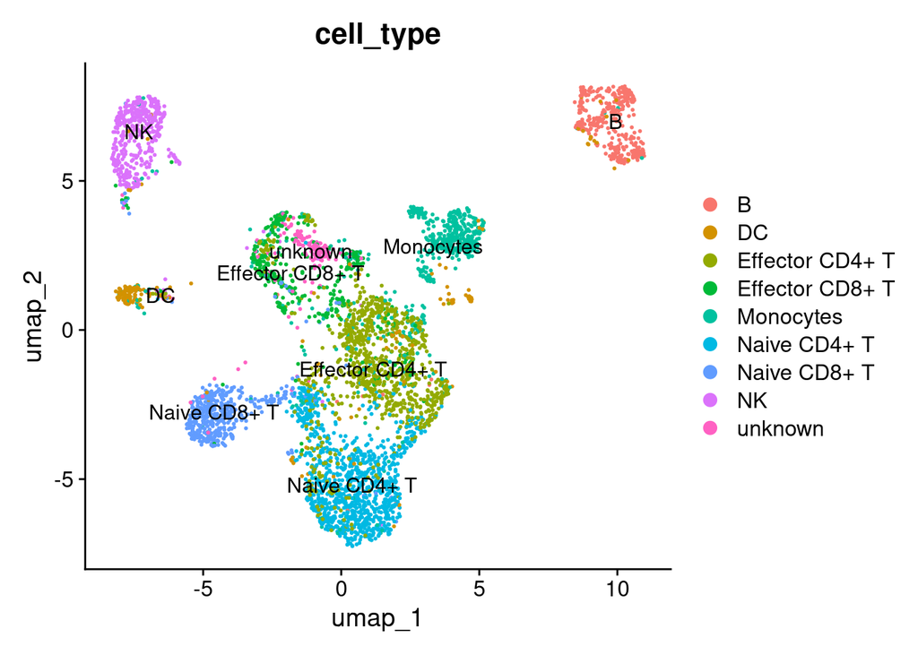

```r
DimPlot(pbmc_atac,reduction = 'umap',label = TRUE,group.by = 'cell_type')
```

## Stage 2: Metacell construction

In practice, due to the high sparsity and noise inherent in single-cell data, directly learning cross-modal mappings from the single-cell level data is challenging. To address this, SuperMap follows the approach established in previous studies by aggregating closely similar cells into ‘’meta-cell’’ to enhance the signal-to-noise ratio. Next, we demonstrate how to construct the meta-cell data.

```r
## The clustering resolution can be flexibly adjusted
pbmc_adt = metacell_construct(object = pbmc_adt, resolution = 15, graph.name = 'ADT_snn')
```

```
## Modularity Optimizer version 1.3.0 by Ludo Waltman and Nees Jan van Eck
##
## Number of nodes: 4502
## Number of edges: 187148
##
## Running Louvain algorithm...
## Maximum modularity in 10 random starts: 0.1981
## Number of communities: 119
## Elapsed time: 0 seconds
```

```
## 1 singletons identified. 118 final clusters.
```

```r
pbmc_atac = metacell_construct(object = pbmc_atac, resolution = 15, graph.name = 'ATAC_snn')
```

```
## Modularity Optimizer version 1.3.0 by Ludo Waltman and Nees Jan van Eck
##
## Number of nodes: 4502
## Number of edges: 183725
##
## Running Louvain algorithm...
## Maximum modularity in 10 random starts: 0.3526
## Number of communities: 100
## Elapsed time: 0 seconds
```

```
## 4 singletons identified. 96 final clusters.
```

```r
metacell_adt <- metacell_matrix_ADT(object = pbmc_adt,cluster.name = "seurat_clusters")
metacell_atac <- metacell_matrix_ATAC(object = pbmc_atac,cluster.name = "seurat_clusters")
```

At this point, we obtained metacell-level data for model fitting.

## Stage 3: Computing peak-gene distance

SuperMap incorporates genomic proximity as prior knowledge to regularize the model. Therefore, we need to compute the genomic distances between protein-coding genes in the ADT modality and peaks in the ATAC modality. First, we convert protein names to their corresponding gene names.

```r
rna_protein_conversion = read.csv(file = 'ASAP_data/rna_protein_correspondence.txt',header = FALSE, sep = ',')

adt_name = sub("^ADT-", "", colnames(metacell_adt))
colnames(metacell_adt) = adt_name
rna_protein_conversion = rna_protein_conversion[rna_protein_conversion$V2 %in% adt_name,]
metacell_adt = metacell_adt[,rna_protein_conversion$V2]
colnames(metacell_adt) = rna_protein_conversion$V1

gene_annotation = read.table('~/pbmc_pair_cpm/GRCh38_cellranger2020.gene_location.txt',sep = ' ',header = TRUE)   ## Read the genomic coordinates of all genes.

supermap_data = gene_peak_distance(rna = metacell_adt, atac = metacell_atac,gene_annotation = gene_annotation)
```

## Stage 4: Run SuerpMap

At this stage, we run SuperMap on the preprocessed data to fit the model and learn the cross-modal mappings.

```r
learned_mappings = supermap(input_data = supermap_data)
```

The returned results include the convergence information of the model and the estimated parameters. We first plot the convergence curve for this run to check the iteration process.

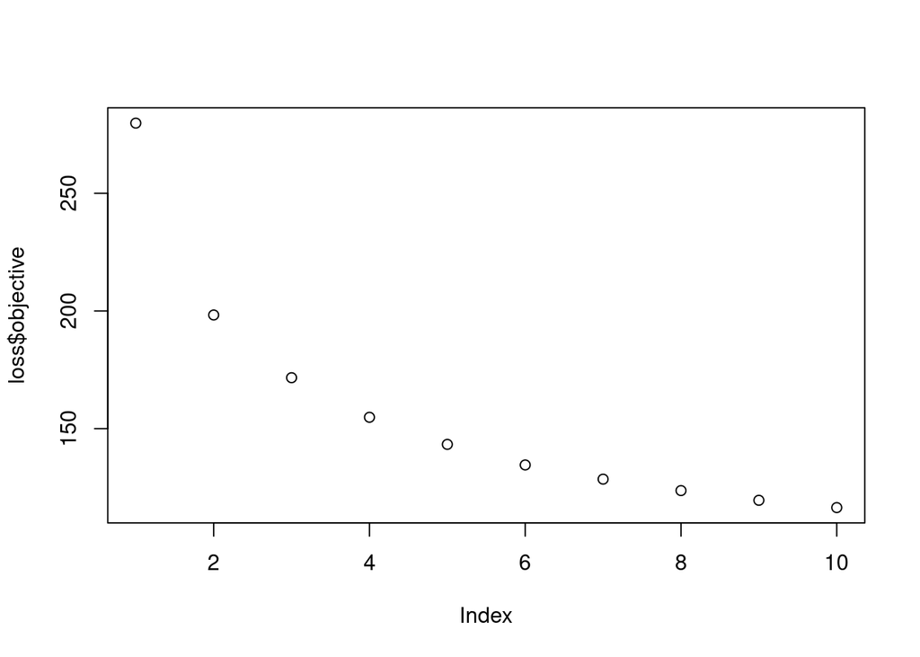

```r
loss = learned_mappings$convergence
loss = as.data.frame(loss)

colnames(loss) = c('residual','objective')
loss$iter = c(1:nrow(loss))

plot(loss$objective)
```

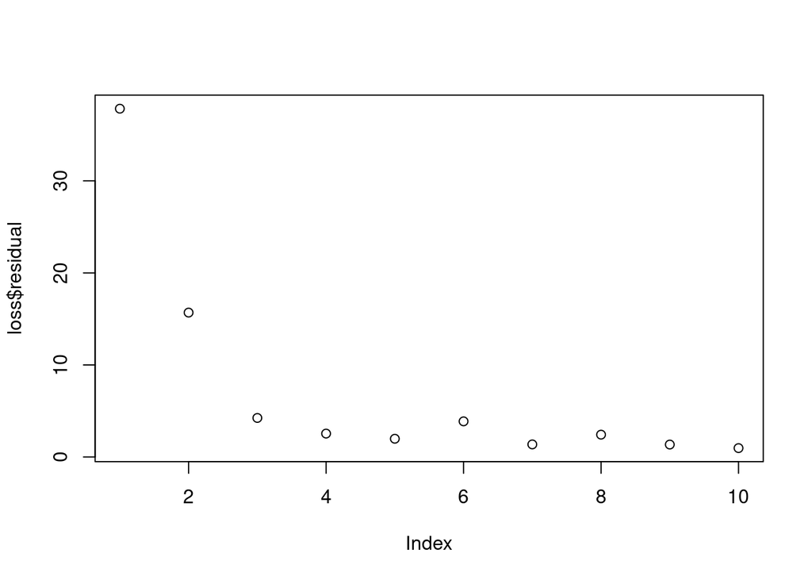

```r
plot(loss$residual)
```

We observed that the objective function steadily converged over iterations.

## Stage 4: Imputating missing modality

The learned mappings can be used for extensive downstream integrative analyses of unpaired multimodal data, including imputing missing modalities to enhance cell type identification. Below, we demonstrate how to predict protein expression from chromatin accessibility.

```r
imputation_data = imputation(supermap_data = supermap_data,learned_mappings = learned_mappings,atac=pbmc_atac)
```

After obtaining the imputed protein expression profiles, we can use marker gene signals to interpret the cell clusters. We visualized the expression patterns of several representative markers to facilitate biological interpretation.

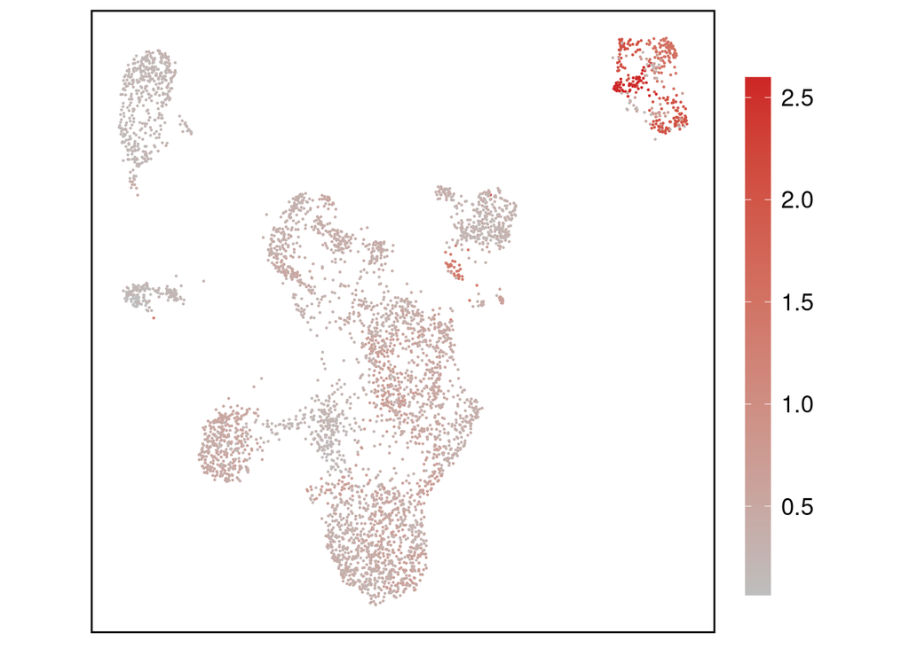

```r
cell_umap = pbmc_atac@reductions$umap@cell.embeddings
cell_umap = as.data.frame(cell_umap)
cell_umap$imputed_value = imputation_data[rownames(cell_umap),'CXCR5']
marker_plot(cell_umap = cell_umap)
```

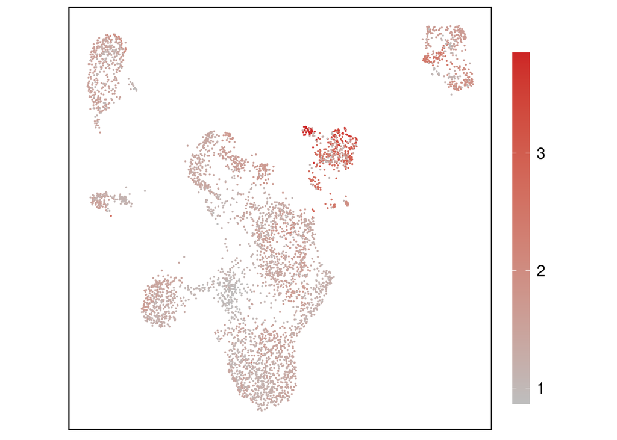

```r
cell_umap = pbmc_atac@reductions$umap@cell.embeddings
cell_umap = as.data.frame(cell_umap)
cell_umap$imputed_value = imputation_data[rownames(cell_umap),'CD14']
marker_plot(cell_umap = cell_umap)
```